# Jupyter Notebooks in the Classroom

Eric Van Dusen

2026-11-19

## Jupyter Notebooks in the Classroom

Meeting students and faculty where they are

**Eric Van Dusen**  
Universidad Europea de Madrid  
19 November 2026  
github.com/ericvd-ucb

[figure not shown]

## Plan for today

### Talk, 40 minutes

- My path into notebooks
- How notebooks grew at Berkeley
- Design principles for faculty
- Jupyter at UEM today
- From notebook to LORCA

### Hands-on, 40 minutes

- Open a notebook in Google Colab
- Reproduce a published chart on the Spanish economy
- Change the indicator or time period
- Discuss how to adapt it for your course

## Disambiguation: what is Jupyter?

### 1. A file type

A notebook is an `.ipynb` file, stored as JSON.

One file holds Markdown text, code and the computational outputs.

### 2. A way to scaffold compute

The notebook plus its packages and environment files.

Together they make sure the compute works anywhere.

### 3. A software IDE

JupyterLab and Jupyter Notebook open and run notebook files.

You can also work in Google Colab, VS Code and others.

## My path into notebooks

- My background is in international development
- A new role at Berkeley let me teach a new International Development course
- The course was built on notebooks from the start
- LS 88: Behind the Curtain in International Development

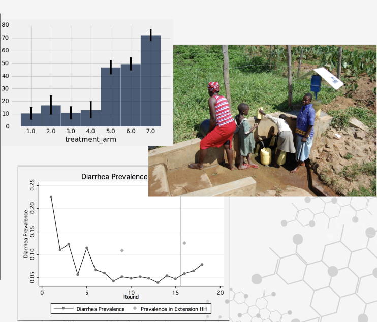

## A development course in notebooks

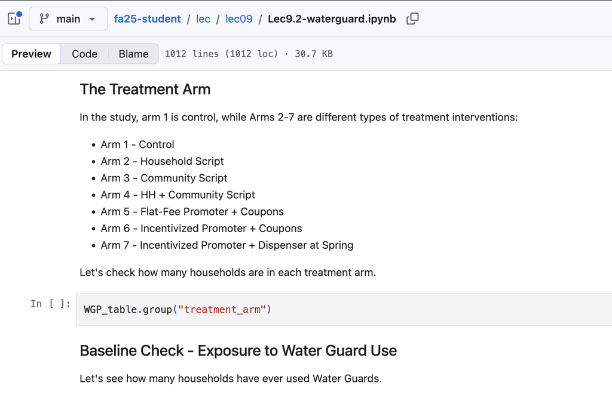

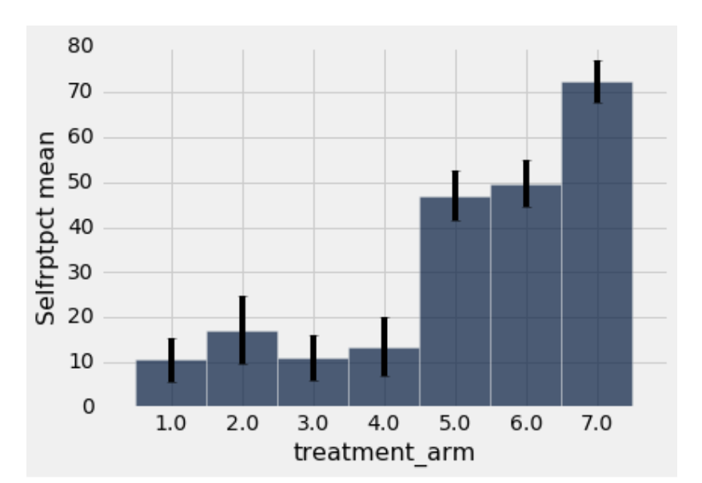

Lecture 9.2, WaterGuard study notebook, fa25-student repository

The course began from questions in development economics. The notebook was the tool for working on them.

## What that first course taught me

### Real data

Students worked directly with development data from the first week.

Data from the WaterGuard household water treatment study.

This data was also in published journal articles.

### What worked

Taking students from messy field data to the research behind Nobel-winning development economics.

### What surprised me

Students with a little bit of python can do a lot on a scaffolded path

Students are hungry for real world applications

It started me on a path I am still on: helping other faculty teach with Jupyter.

## Data 8: Foundations of Data Science

[figure not shown]

- Introductory course open to students in any major
- No prerequisites in programming or statistics
- Real questions and real data from the first lecture
- Python introduced as students need it, inside notebooks

[figure not shown]

Open textbook: Adhikari, DeNero and Wagner, *Computational and Inferential Thinking*, inferentialthinking.com

## The Data Science Connectors model

- Connector courses are taken alongside Data 8
- Each one applies the same tools to a single discipline
- Faculty in that discipline design and teach them
- Students see the methods used on questions from their own field

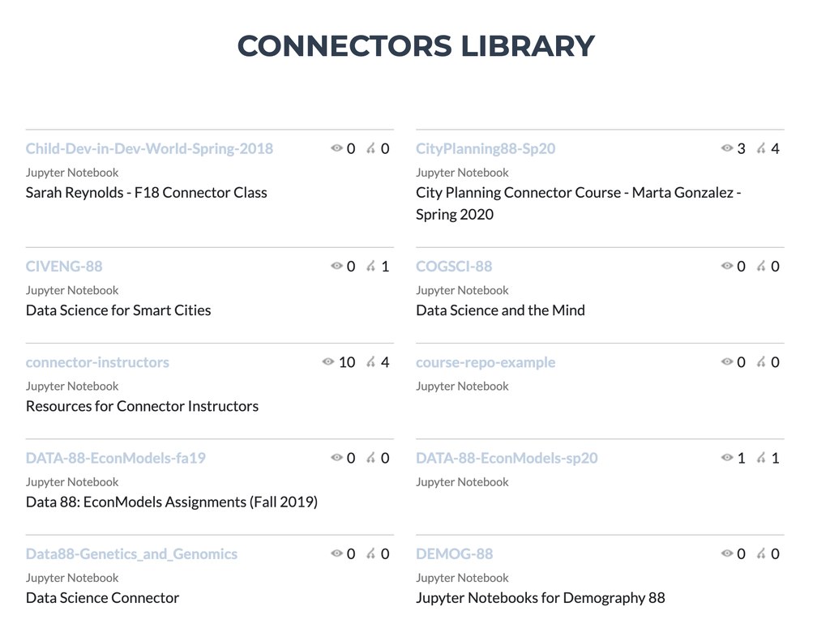

Connectors Library: public notebook repositories for connector courses

## Data 88E: Economic Models

- A connector course in economics
- Economic models taught through notebooks
- Students work with economic data alongside the theory
- Open materials that other institutions have adapted

[figure not shown]

*Data 88E: Economic Models Textbook*, Budget Constraints and Utility Maximization. data-88e.github.io/textbook

## Ten years of notebooks at Berkeley

### 10

years of notebook-based courses

### Dozens

of faculty teaching with notebooks

### Hundreds

of notebooks in open course materials

### 10,000s

of students

Most of this growth came from faculty in other departments adapting materials they had seen working.

## Start from your existing assignments

- Excel exercise or lab book
- Same question in a notebook
- Same learning goal
- Begin with an assignment you already teach and trust
- Keep the question and the data; change the tool
- The learning goals of the course stay the same

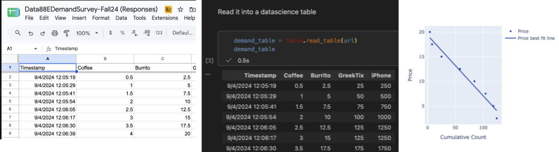

Data 88E, fall 2024: class demand survey in a spreadsheet, read into a notebook, plotted as a demand curve

## Teach only the Python needed

- Introduce code inside the notebook, at the point where it is used
- A few operations cover most course work: load a table, select, group, plot
- Give students working code to read and modify before they write their own
- Leave programming courses to teach programming

How much Python does your course actually need?

## Learning a new Python package

- Read the docs
- Supply data
- Configure
- Run
- Interpret
- In Econ 148, students meet new data and ML packages every few weeks and learn to use them productively.
  - NumPy → statsmodels → scikit-learn
- AI tools expose similar Python interfaces and APIs, and the same pattern applies.
  - PyTorch, TensorFlow, the OpenAI API

Moving through the Data Science major is a progression of learning new Python packages.

[figure not shown]

## Scaffold to the students’ level

1

### Run and read

Students run prepared cells and interpret the output.

2

### Modify

Students change a variable, a filter or a time period and explain the difference.

3

### Write

Students write their own analysis on a new question.

## Feedback through autograding

- Tests are written into the notebook
- Students check their work as they go
- Instructors grade at scale with the same tests
- Berkeley uses otter-grader, which is open source

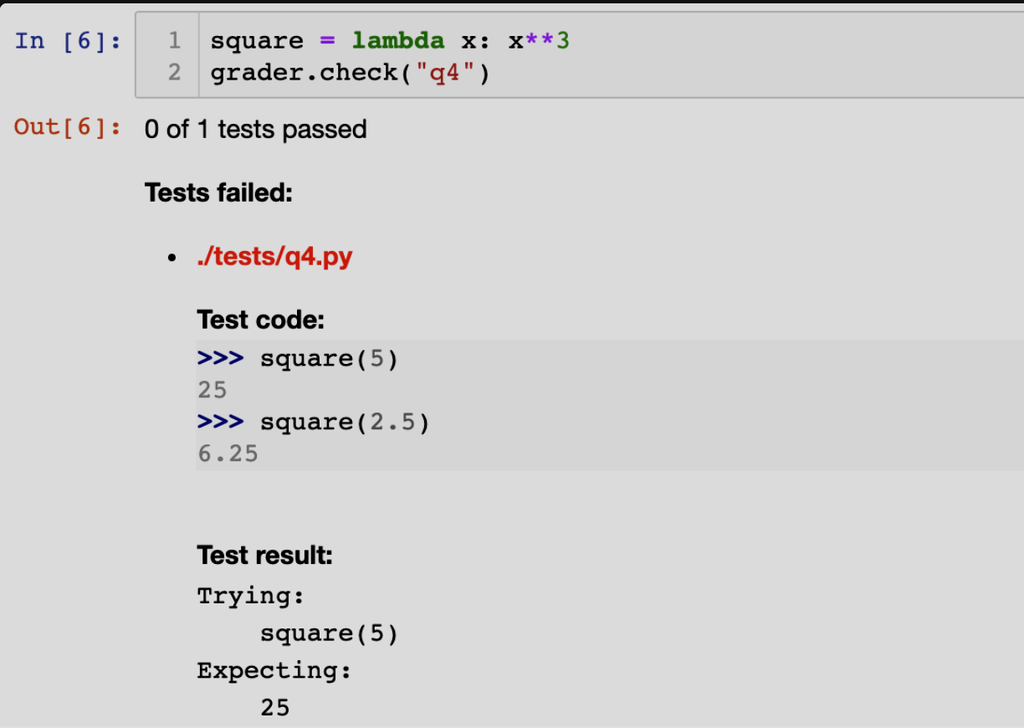

otter-grader: otter-grader.readthedocs.io

## Metacognition 1: Notebook-based instruction

- Code, narrative, data, visualizations and results in one environment
- Students start with real questions and working examples, then modify them
- Programming and math concepts arrive in the context of a substantive problem

[figure not shown]

inferentialthinking.com

Is notebook-based instruction changing the way we teach computing, math and science?

## Metacognition 2: Why are we learning this way?

Jupyter, NumPy, Python APIs and cloud environments are not only classroom conveniences.

They are part of the scientific and professional computing ecosystem.

- Students learn to explore, troubleshoot, adapt and build with the same tools professionals use.
- Students can adapt to new technologies as they emerge.
- Notebooks suit project-based learning and work in small teams, but you have to teach some key behaviors.
- *Faculty need to keep evolving the curriculum to reflect changes in the professional ecosystem.*

## Metacognition 3: Teaching through the open-source stack

Data Science courses teach with open-source tools, so students learn the same stack used in research and industry.

### Origins

IPython and Jupyter grew out of scientific computing and open research communities.

### An open stack

Python, NumPy, pandas and Jupyter are open-source projects maintained by communities.

### Reproducibility

Notebooks make methods and outputs shareable. Reproducing them also depends on environments, dependencies, data access and execution order.

I publish all my materials openly on the web, using only public data and images. I want academia to become more open.

## Jupyter at UEM today

### Gabriel Marín Díaz

Open data courses and reproducible articles

### Marcos López-Caniego Alcarria

Notebooks for ESA Euclid mission data

### Javier Acosta

AlphaFold peptide design challenge on Google Cloud

Also in development: courses by María Cruz Gaya López and José Naveiro.

## Euclid notebooks: Marcos López-Caniego

[figure not shown]

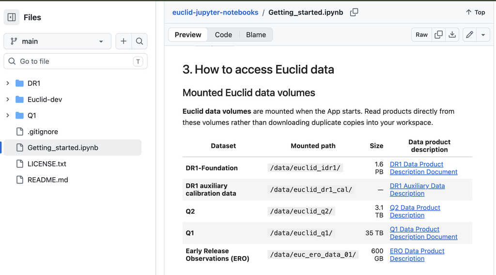

- JupyterCon talk on astronomical data exploration with Jupyter
- Getting-started notebooks for ESA Euclid mission data

López-Caniego et al., “Closing the loop from astronomical data exploration to scientific discovery using the Jupyterverse,” JupyterCon. European Space Astronomy Centre, Madrid. youtube.com/watch?v=VKOz1v3bFVk

## Peptide design challenge: Javier Acosta

- Third-year Biomedicine, Biotechnology and Pharmacy students
- 18 mixed teams, each with a disease-linked target
- Peptide design with AlphaFold in a Colab notebook on Google Cloud
- Selected teams defended their results

[figure not shown]

Acosta and Del Arco, “Artificial intelligence-guided therapeutic peptide design: a challenge-based learning experience in biomedical education,” ICERI 2026.

## Courses in development at UEM

### María Cruz Gaya López

Computación Científica I: from a CSV file to an analysis project, using NASA’s Meteorite Landings open data

[figure not shown]

### José Naveiro

Metal cutting: cutting speed and spindle speed for turning a steel shaft, calculated step by step

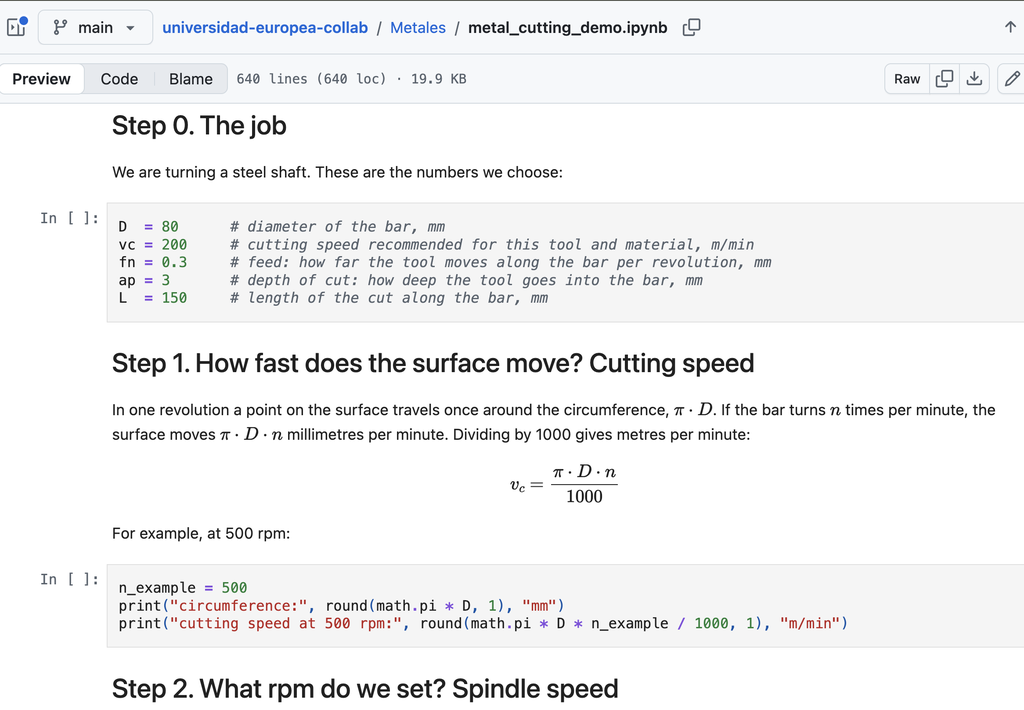

Notebooks in the universidad-europea-collab repository on GitHub

## From notebook to LORCA

- Notebook in Colab
- Jupyter on LORCA
- Research computing
- LORCA: Laboratorio Optimizado de Recursos de Computación Avanzada
- Students who can use Jupyter and Python can use LORCA
- 16 nodes with 1,200 CPU cores, 1.9 TB of RAM, 42 TB of storage and 10 NVIDIA GPUs

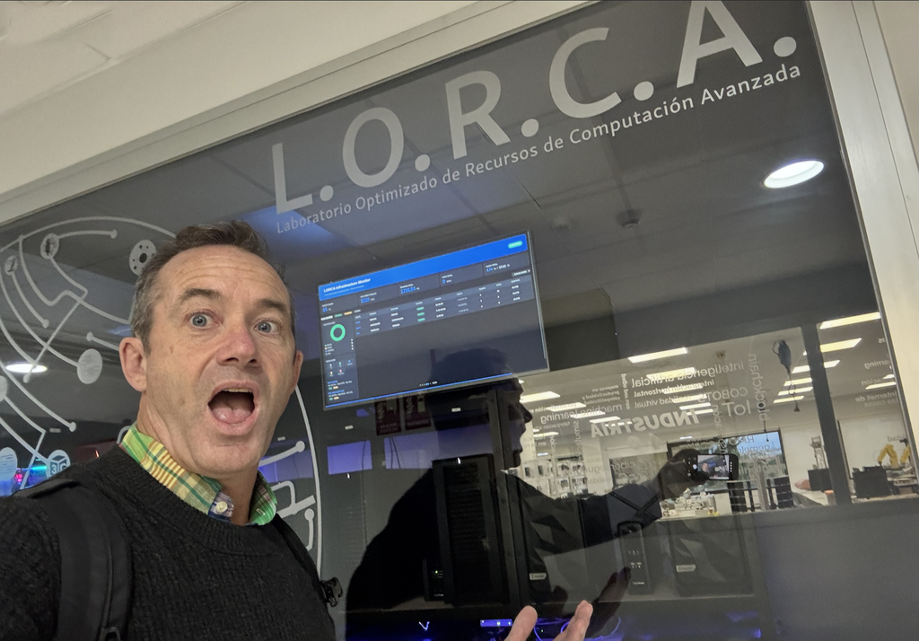

## Hands-on

Reproducing a chart about the Spanish economy

## How to get to the notebook

github.com/ericvd-ucb

- universidad-europea-collab repo
- README
- Open in Colab link
- Sign in with a Google account
- Nothing to install

github.com/ericvd-ucb/universidad-europea-collab

## Some notes on Colab

### No sense of paths

Be careful how you address files that go with the notebook.

I point to files by their address on GitHub.

### AI help built in

Colab has an AI assistant installed.

It will suggest code as you type.

### Good for group work

Share one notebook with a group.

Students can work in it together.

## Can we reproduce this chart?

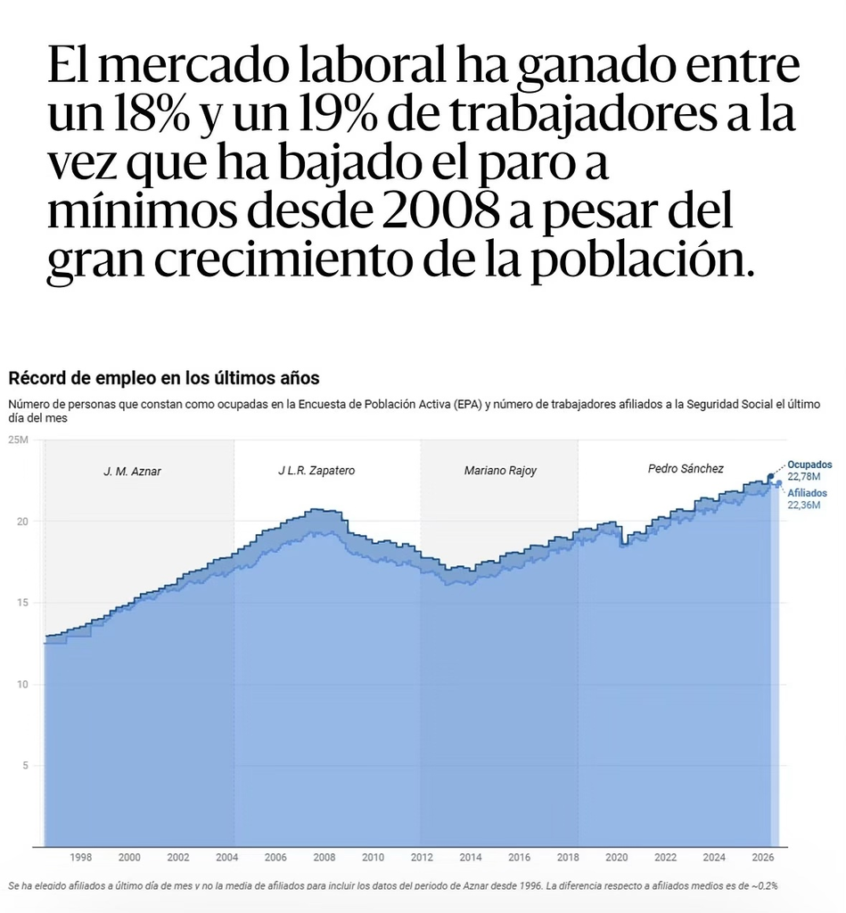

- A chart of employment in Spain by presidential term, shared on social media and in the press
- Two series: employed persons in the EPA survey and workers registered with Social Security
- We will find the data, rebuild the chart and check the headline

The question is about data and careful reading, not about politics.

El Diario, Instagram post. [instagram.com/p/DeXZ-VrGlI6](https://www.instagram.com/p/DeXZ-VrGlI6/)

## Notebook basics in Colab

[figure not shown]

- Text cells and code cells
- Run a cell with Shift + Enter
- Run cells in order, from the top
- Save a copy to your own Drive

## Steps for the session

- Open spain_economy_by_term.ipynb from the README
- Run the cells that load the data
- Reproduce the published chart
- Change an indicator or time period
- Discuss how you would adapt this for your course

## Discussion

How would you adapt this for your own course?

- Which existing assignment could become a notebook?
- What data do your students already use?
- What would students need to know first?

Materials: github.com/ericvd-ucb/universidad-europea-collab